# Ridge & Lasso Modeling of Clade C Bacteria

Cassandra Sperow

2023-11-14

# Review Goal & Question(s)

- Can Clade C bacteria be modeled using classification algorithms?
- When Clade C bacteria are modeled, which bacteria strains (ASVs) seem to be the ‘best’, or most associated, predictors of Clade C?

# Import Logistic Regression Balanced Dataset

- Clade C: n=139
- Non-Clade C: n=139
- Use first 1000 ASVs obtained in PCA Dim.1
- The `lr_data.csv` dataset was created by subsetting the Clade C observations from the original 659 samples with random sampling from non-Clade C rows to obtain an equal number of observations for each response label of Clade C = 1, Non-Clade C = 0. This data subsetting process was obtained in the original modeling exploration file ‘Logistic Regression Clade C.Rmd’.
- The Clade C Principal Components Analysis results from dimension 1 were obtained in the file ‘PCA-CLR.Rmd’.
- The ASV data are transformed for modeling with the centered log ratio of the raw abundance counts. This is redone when subsetting for the PCA 1000 results and again when subsetting the first 500 PCA results.

```r
# read in balanced Clade C and non-Clade C observations
read_csv( "../output/lr_data.csv") -> lr_data
# read in saved PCA ranks for Dimension 1
read_csv("../output/clade_c_pca_Ranks.csv") -> clade_c_pca_Ranks
# order the Clade C ASVs by selecting from the vector of PCA results
lr_data %>%
  select(sample_id, Clade, (clade_c_pca_Ranks$ASV)) %>%
  select(1:1002) -> lr_data_1000

dim(lr_data_1000)
```

```
## [1]  278 1002
```

```r
#glimpse(lr_data)
head(lr_data_1000)
```

```
## # A tibble: 6 × 1,002
##   sample_id  Clade ASV1236 ASV0421 ASV0691 ASV0899 ASV1004 ASV1041 ASV1058
##   <chr>      <dbl>   <dbl>   <dbl>   <dbl>   <dbl>   <dbl>   <dbl>   <dbl>
## 1 SKAU-R2-23     1       0       0       0       0       0       0       0
## 2 SWAJ-R4-3      0       0       0       0       0       0       0       0
## 3 SYAN-R3-19     1       0       0       0       0       0       0       0
## 4 PMAQ-R2-19     0       0       0       0       0       0       0       0
## 5 SDOG-R3-6      0       0       0       0       0       0       0       0
## 6 PDOG-R2-22     0     234     147      90     103      60      42      49
## # ℹ 993 more variables: ASV12542 <dbl>, ASV1294 <dbl>, ASV13113 <dbl>,
## #   ASV1318 <dbl>, ASV2269 <dbl>, ASV2542 <dbl>, ASV2660 <dbl>, ASV2737 <dbl>,
## #   ASV2840 <dbl>, ASV3053 <dbl>, ASV3077 <dbl>, ASV3134 <dbl>, ASV3140 <dbl>,
## #   ASV3579 <dbl>, ASV6119 <dbl>, ASV7557 <dbl>, ASV8422 <dbl>, ASV1086 <dbl>,
## #   ASV1310 <dbl>, ASV15750 <dbl>, ASV16905 <dbl>, ASV2033 <dbl>,
## #   ASV2089 <dbl>, ASV2127 <dbl>, ASV2725 <dbl>, ASV2804 <dbl>, ASV3075 <dbl>,
## #   ASV3327 <dbl>, ASV3342 <dbl>, ASV3532 <dbl>, ASV3600 <dbl>, …
```

### Centered-Log-Ratio Data Transformation of 1000 ASV Numeric Columns

```r
library(compositions)
# CLR Data Transformation on only ASV numeric columns
bind_cols(lr_data_1000[,1:2], # sample id and Clade columns
          # re-do CLR transformation on relative first 1000 PCA
          lr_data_1000[,-c(1,2)] %>% clr()
            ) -> lr_clr_df_1000
```

```r
head(lr_clr_df_1000)
```

```
## # A tibble: 6 × 1,002
##   sample_id  Clade ASV1236 ASV0421 ASV0691 ASV0899 ASV1004 ASV1041 ASV1058
##   <chr>      <dbl>   <dbl>   <dbl>   <dbl>   <dbl>   <dbl>   <dbl>   <dbl>
## 1 SKAU-R2-23     1    0      0       0       0      0        0       0
## 2 SWAJ-R4-3      0    0      0       0       0      0        0       0
## 3 SYAN-R3-19     1    0      0       0       0      0        0       0
## 4 PMAQ-R2-19     0    0      0       0       0      0        0       0
## 5 SDOG-R3-6      0    0      0       0       0      0        0       0
## 6 PDOG-R2-22     0    1.38   0.913   0.423   0.557  0.0171  -0.340  -0.185
## # ℹ 993 more variables: ASV12542 <dbl>, ASV1294 <dbl>, ASV13113 <dbl>,
## #   ASV1318 <dbl>, ASV2269 <dbl>, ASV2542 <dbl>, ASV2660 <dbl>, ASV2737 <dbl>,
## #   ASV2840 <dbl>, ASV3053 <dbl>, ASV3077 <dbl>, ASV3134 <dbl>, ASV3140 <dbl>,
## #   ASV3579 <dbl>, ASV6119 <dbl>, ASV7557 <dbl>, ASV8422 <dbl>, ASV1086 <dbl>,
## #   ASV1310 <dbl>, ASV15750 <dbl>, ASV16905 <dbl>, ASV2033 <dbl>,
## #   ASV2089 <dbl>, ASV2127 <dbl>, ASV2725 <dbl>, ASV2804 <dbl>, ASV3075 <dbl>,
## #   ASV3327 <dbl>, ASV3342 <dbl>, ASV3532 <dbl>, ASV3600 <dbl>, …
```

# Training and Testing Split - 85 % Training

```r
set.seed(1234)
Z <- sample(nrow(lr_clr_df_1000), .85*nrow(lr_clr_df_1000))
lr_train <- lr_clr_df_1000[Z,]
lr_test <- lr_clr_df_1000[-Z,]

# take a peek at training data
head(lr_train)
```

```
## # A tibble: 6 × 1,002
##   sample_id  Clade ASV1236 ASV0421 ASV0691 ASV0899 ASV1004 ASV1041 ASV1058
##   <chr>      <dbl>   <dbl>   <dbl>   <dbl>   <dbl>   <dbl>   <dbl>   <dbl>
## 1 PWAJ-R3-8      0       0       0       0       0       0       0       0
## 2 SYAN-R1-11     1       0       0       0       0       0       0       0
## 3 SMAQ-R1-5      1       0       0       0       0       0       0       0
## 4 PWAJ-R3-1      0       0       0       0       0       0       0       0
## 5 SYAN-R1-16     1       0       0       0       0       0       0       0
## 6 PMAQ-R2-29     1       0       0       0       0       0       0       0
## # ℹ 993 more variables: ASV12542 <dbl>, ASV1294 <dbl>, ASV13113 <dbl>,
## #   ASV1318 <dbl>, ASV2269 <dbl>, ASV2542 <dbl>, ASV2660 <dbl>, ASV2737 <dbl>,
## #   ASV2840 <dbl>, ASV3053 <dbl>, ASV3077 <dbl>, ASV3134 <dbl>, ASV3140 <dbl>,
## #   ASV3579 <dbl>, ASV6119 <dbl>, ASV7557 <dbl>, ASV8422 <dbl>, ASV1086 <dbl>,
## #   ASV1310 <dbl>, ASV15750 <dbl>, ASV16905 <dbl>, ASV2033 <dbl>,
## #   ASV2089 <dbl>, ASV2127 <dbl>, ASV2725 <dbl>, ASV2804 <dbl>, ASV3075 <dbl>,
## #   ASV3327 <dbl>, ASV3342 <dbl>, ASV3532 <dbl>, ASV3600 <dbl>, …
```

```r
dim(lr_train) # 236 x 1002
```

```
## [1]  236 1002
```

```r
dim(lr_test) # 42 x 1002
```

```
## [1]   42 1002
```

# Check Data

### Class Label Distributions of Training & Testing Data

- Clade C and Non-Clade C histogram

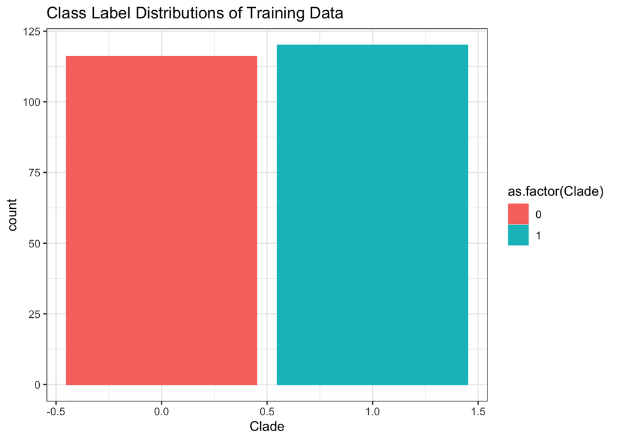

```r
ggplot(lr_train, aes( x = Clade, color = as.factor(Clade), fill = as.factor(Clade))) +
  geom_histogram(stat = 'count') +
  ggtitle("Class Label Distributions of Training Data") +
  theme_bw()
```

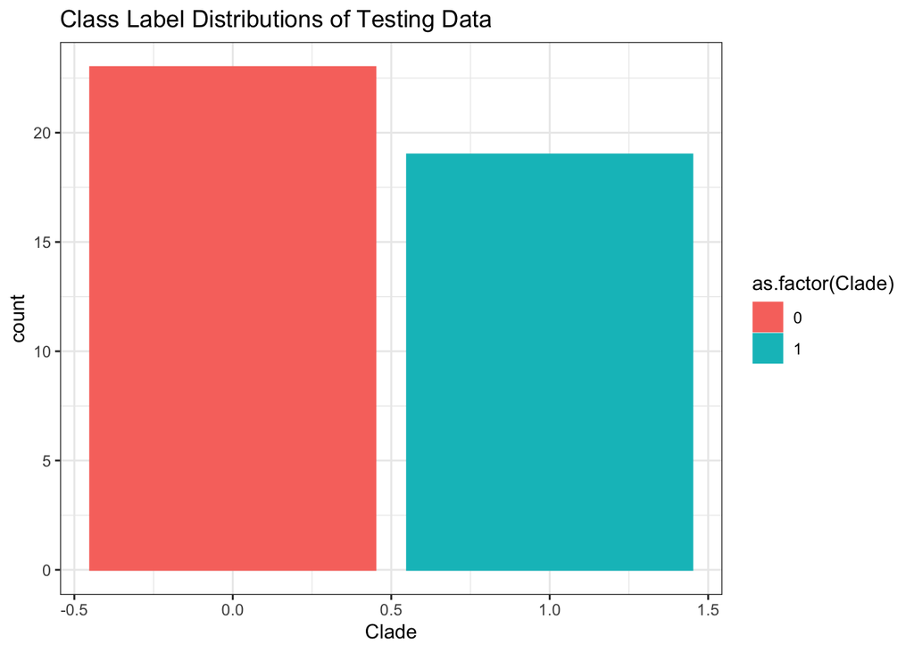

```r
ggplot(lr_test, aes( x = Clade, color = as.factor(Clade), fill = as.factor(Clade))) +
  geom_histogram(stat = 'count') +
  ggtitle("Class Label Distributions of Testing Data") +
  theme_bw()
```

# Ridge 1000

#### Training

- `glmnet` documentation:

https://glmnet.stanford.edu/articles/glmnet.html

```r
library(glmnet)
# create model matrix for glmnet
#stats::model.matrix()

# Create a formula for model.matrix
formula <- as.formula(paste("Clade ~ .", sep = "", collapse = ""),
                      env = environment(lr_train))

# Create the design matrix
# take out the sample id
x_train <- stats::model.matrix(formula, data = lr_train[,-c(1)])
dim(x_train)
```

```
## [1]  236 1001
```

```r
# Convert the response variable to a numerical vector
# glmnet expects 0/1 coding for binary response
y_train <- lr_train$Clade
length(y_train)
```

```
## [1] 236
```

```r
# Train the RIDGE model
RR <- glmnet(x_train[,-1], # take out intercept
             y_train,
             alpha = 0,  # RIDGE
             family = "binomial")
```

### RR Plot

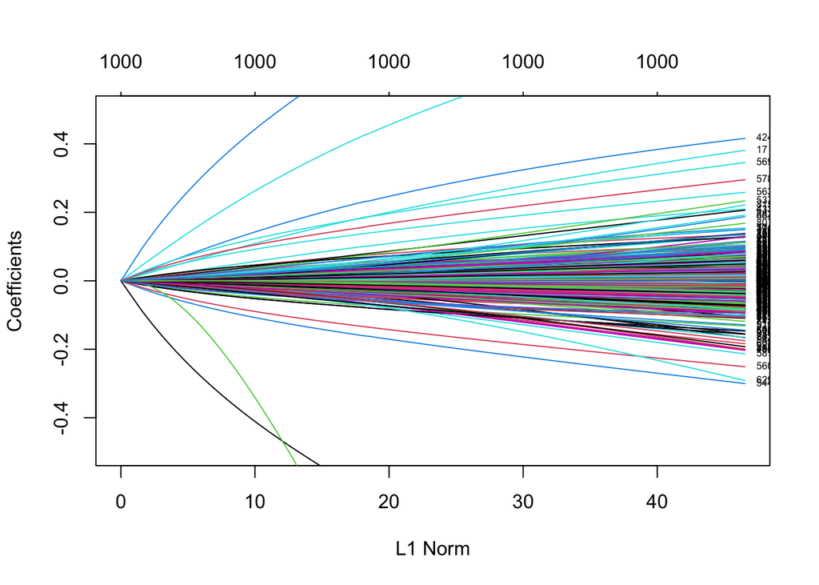

```r
base::plot(RR,
     ylim = c(-0.5, 0.5),
     label = TRUE
     )
```

#### Training Cross-Validation

```r
set.seed(123)
rr_cv <- cv.glmnet(x_train[,-1],
                   y_train,
                   alpha = 0, # Ridge
                   type.measure = "class", # must have for classification
                   family = "binomial" # classification
                   )
rr_cv
```

```
##
## Call:  cv.glmnet(x = x_train[, -1], y = y_train, type.measure = "class",      alpha = 0, family = "binomial")
##
## Measure: Misclassification Error
##
##     Lambda Index Measure      SE Nonzero
## min  6.034    71  0.3347 0.03668    1000
## 1se 20.225    45  0.3644 0.03952    1000
```

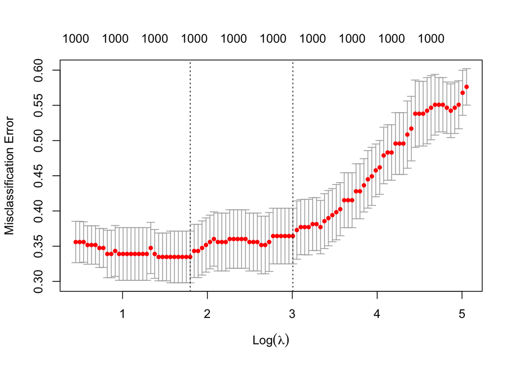

```r
base::plot(rr_cv)
```

#### Best Ridge Model 1000 from Training & Cross-Validation

```r
# Refit the model with the selected lambda
best_RR_1000 <- glmnet(x_train[,-1], # take out intercept bc it will fit another one
                       y_train,
                       family = "binomial",
                       alpha = 0, # Ridge
                       lambda = rr_cv$lambda.min )

#coef(best_RR_1000) %>% as.matrix()
#best_RR_1000
```

#### Ridge Testing 1000

```r
dim(lr_test) # 42 x 1002
```

```
## [1]   42 1002
```

```r
x_test <- stats::model.matrix(formula,
                              data = lr_test[,-c(1)]
                              )
y_test <- lr_test$Clade
```

```r
predict(best_RR_1000,
        newx =  x_test[,-1], # take out intercept bc it will fit a new one
        type = "class", # must have for misclass rate
        s = "lambda.min" # min from training cross-validation
          ) -> yhat
```

```r
# error rate
mean((as.numeric(yhat) - y_test)^2) -> ridge_1000_error
ridge_1000_error
```

```
## [1] 0.3095238
```

```r
# confusion matrix
table(yhat, y_test)
```

```
##     y_test
## yhat  0  1
##    0 13  3
##    1 10 16
```

```r
# correct classification rate
paste("Correct Classification Rate: ", round((13 + 16)/42, 2  ))# 42 testing rows
```

```
## [1] "Correct Classification Rate:  0.69"
```

```r
# Error Rate
#paste("Error Rate: ", round( (13/42), 3))
paste("Error rate: ", round(ridge_1000_error, 2))
```

```
## [1] "Error rate:  0.31"
```

# Ridge 500

### Data Prep

- Subset from original counts for the first 500 ASVs from PCA results

```r
# subset the first 500
lr_data_1000[, 1:502] -> lr_data_500

# redo CLR transformation with counts for first 500
bind_cols(lr_data_500[,1:2],
          lr_data_500[,-c(1,2)] %>% clr()
            ) -> lr_clr_500
```

```r
set.seed(1234)
Z <- sample(nrow(lr_clr_500), .85*nrow(lr_clr_500))
lr_train_500 <- lr_clr_500[Z,]
lr_test_500 <- lr_clr_500[-Z,]

# take a peek at training data
head(lr_train_500)
```

```
## # A tibble: 6 × 502
##   sample_id  Clade ASV1236 ASV0421 ASV0691 ASV0899 ASV1004 ASV1041 ASV1058
##   <chr>      <dbl>   <dbl>   <dbl>   <dbl>   <dbl>   <dbl>   <dbl>   <dbl>
## 1 PWAJ-R3-8      0       0       0       0       0       0       0       0
## 2 SYAN-R1-11     1       0       0       0       0       0       0       0
## 3 SMAQ-R1-5      1       0       0       0       0       0       0       0
## 4 PWAJ-R3-1      0       0       0       0       0       0       0       0
## 5 SYAN-R1-16     1       0       0       0       0       0       0       0
## 6 PMAQ-R2-29     1       0       0       0       0       0       0       0
## # ℹ 493 more variables: ASV12542 <dbl>, ASV1294 <dbl>, ASV13113 <dbl>,
## #   ASV1318 <dbl>, ASV2269 <dbl>, ASV2542 <dbl>, ASV2660 <dbl>, ASV2737 <dbl>,
## #   ASV2840 <dbl>, ASV3053 <dbl>, ASV3077 <dbl>, ASV3134 <dbl>, ASV3140 <dbl>,
## #   ASV3579 <dbl>, ASV6119 <dbl>, ASV7557 <dbl>, ASV8422 <dbl>, ASV1086 <dbl>,
## #   ASV1310 <dbl>, ASV15750 <dbl>, ASV16905 <dbl>, ASV2033 <dbl>,
## #   ASV2089 <dbl>, ASV2127 <dbl>, ASV2725 <dbl>, ASV2804 <dbl>, ASV3075 <dbl>,
## #   ASV3327 <dbl>, ASV3342 <dbl>, ASV3532 <dbl>, ASV3600 <dbl>, …
```

```r
dim(lr_train_500) # 236 x 502
```

```
## [1] 236 502
```

```r
dim(lr_test_500) # 42 x 502
```

```
## [1]  42 502
```

```r
# Create a formula for model.matrix using the 500 dataframe
formula <- as.formula(paste("Clade ~ .", sep = "", collapse = ""),
                      env = environment(lr_train_500))

# Create the design matrix
# take out the sample id
x_train_500 <- stats::model.matrix(formula, data = lr_train_500[,-c(1)])
dim(x_train_500) # 501 because there's an intercept
```

```
## [1] 236 501
```

```r
# Convert the response variable to a numerical vector
# glmnet expects 0/1 coding for binary response
y_train_500 <- lr_train_500$Clade
length(y_train_500)
```

```
## [1] 236
```

```r
typeof(y_train_500) # glmnet expects numeric even for classificiation
```

```
## [1] "double"
```

#### Training 500

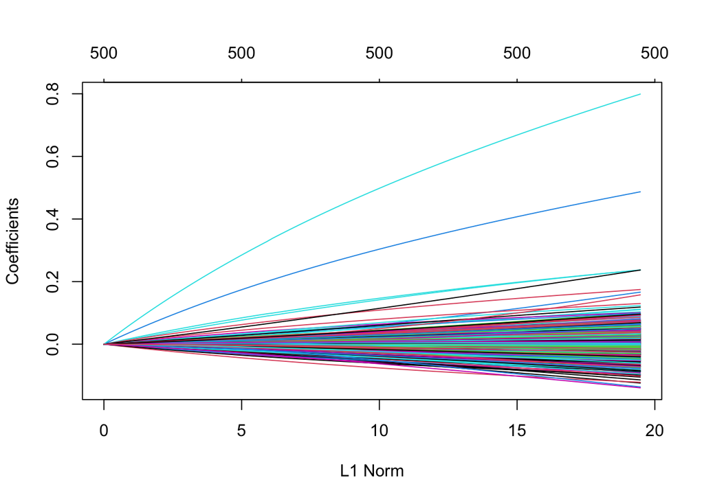

```r
# Train the RIDGE model with 500 ASVs
RR_500 <- glmnet(x = x_train_500[,-1], # take out intercept
                 y = y_train_500,
                 alpha = 0,  # RIDGE
                 family = "binomial") # do not need type = class here

base::plot(RR_500)
```

#### Cross-Validation

```r
set.seed(1234)
rr_500_cv <- cv.glmnet(x = x_train_500[,-1], # take out intercept
                       y = y_train_500,
                       family = "binomial",
                       type.measure = "class")

rr_500_cv
```

```
##
## Call:  cv.glmnet(x = x_train_500[, -1], y = y_train_500, type.measure = "class",      family = "binomial")
##
## Measure: Misclassification Error
##
##      Lambda Index Measure      SE Nonzero
## min 0.07045    19  0.3432 0.02195       6
## 1se 0.12311     7  0.3644 0.03269       1
```

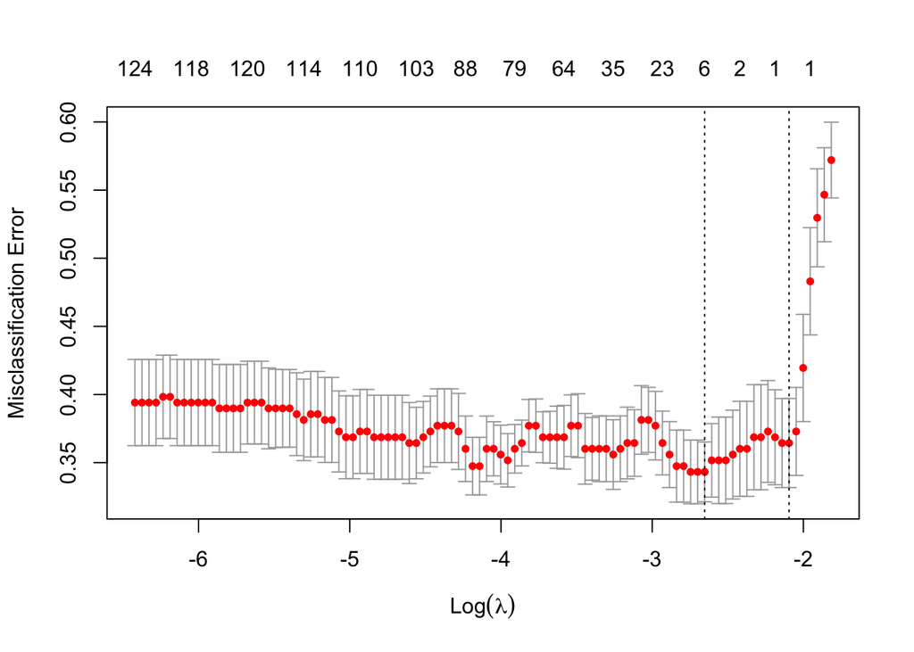

```r
base::plot(rr_500_cv)
```

### Ridge 500 Best Model & Refit

```r
# Refit the model with the selected lambda
best_RR_500 <- glmnet(x = x_train_500[,-1], # take out intercept
                      y = y_train_500,
                      family = "binomial",
                      alpha = 0, # Ridge
                      lambda = rr_500_cv$lambda.min )

best_RR_500
```

```
##
## Call:  glmnet(x = x_train_500[, -1], y = y_train_500, family = "binomial",      alpha = 0, lambda = rr_500_cv$lambda.min)
##
##    Df %Dev  Lambda
## 1 500 61.8 0.07045
```

### Ridge 500 Testing

```r
dim(lr_test_500) # 42 x 502
```

```
## [1]  42 502
```

```r
x_test_500 <- stats::model.matrix(formula,
                              data = lr_test_500[,-c(1)]
                              )
y_test_500 <- lr_test_500$Clade

predict(best_RR_500,
        newx =  x_test_500[,-1], # take out intercept bc it will fit a new one
        type = "class", # must have for misclass rate
        s = "lambda.min" # min from training cross-validation
          ) -> yhat_500
```

```r
mean((as.numeric(yhat_500) - y_test_500)^2) -> ridge_500_error
paste("Error rate: ", round(ridge_500_error, 2))
```

```
## [1] "Error rate:  0.29"
```

```r
paste("Confusion Matrix: ")
```

```
## [1] "Confusion Matrix: "
```

```r
table(yhat_500, y_test_500)
```

```
##         y_test_500
## yhat_500  0  1
##        0 15  4
##        1  8 15
```

```r
paste("Correct Classification Rate: ",
round(((15 + 15)/ 42), 2)
)
```

```
## [1] "Correct Classification Rate:  0.71"
```

- Error rate for using 500 ASVs is 28.6 %
- Correct Classification Rate is 71.4 %

# Lasso 1000

- Using same 1000 column dataframe as Ridge 1000 section above

```r
dim(x_train) # includes intercept
```

```
## [1]  236 1001
```

```r
length(y_train) # 139 clade C = 1, 139 not clade C = 0
```

```
## [1] 236
```

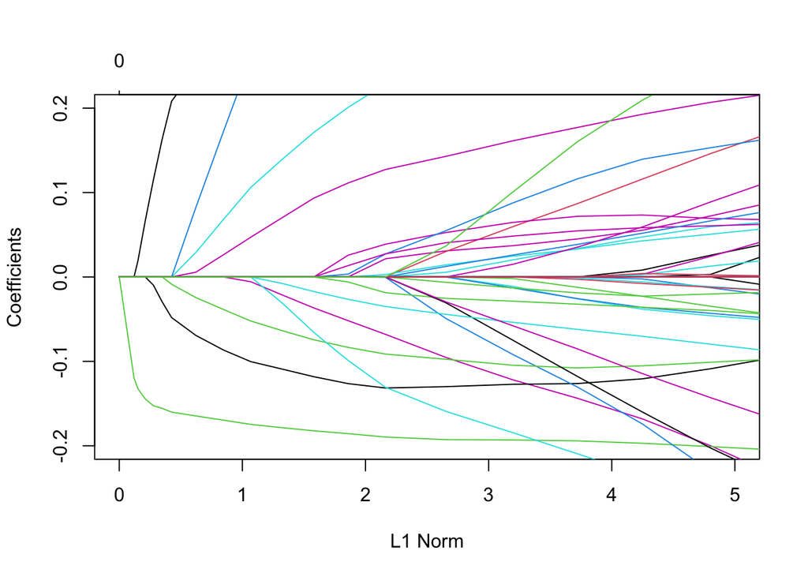

```r
# Train the LASSO model
lasso <- glmnet(x_train[,-1], # take out intercept
             y_train,
             alpha = 1,  # Lasso
             family = "binomial")


base::plot(lasso,
     xlim = c(0, 5),
     ylim = c(-0.2, 0.2)
     )
```

### Lasso CV

```r
set.seed(123)
lasso_cv <- cv.glmnet(x_train[,-1],
                   y_train,
                   alpha = 1, # Lasso
                   type.measure = "class", # must have for classification
                   family = "binomial" # classification
                   )
lasso_cv
```

```
##
## Call:  cv.glmnet(x = x_train[, -1], y = y_train, type.measure = "class",      alpha = 1, family = "binomial")
##
## Measure: Misclassification Error
##
##      Lambda Index Measure      SE Nonzero
## min 0.02934    37  0.3644 0.03800      73
## 1se 0.10303    10  0.3983 0.02197       2
```

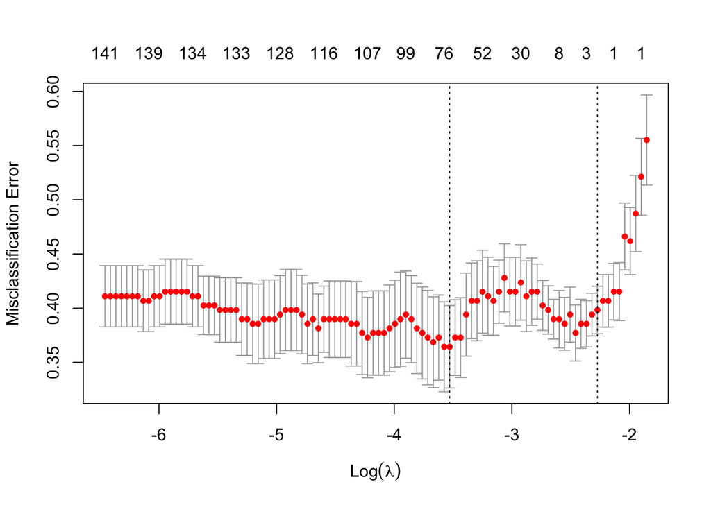

```r
base::plot(lasso_cv)
```

- lambda.min has a lower error rate of 36.4 %
- lambda.min has 73 Non-Zero Coefficients out of 1000 ASVs

```r
# Refit the model with the selected lambda
best_lasso_1000 <- glmnet(x_train[,-1], # take out intercept bc it will fit another one
                       y_train,
                       family = "binomial",
                       alpha = 1, # Lasso
                       lambda = lasso_cv$lambda.min )

#best_lasso_1000
```

### Lasso Testing 1000

```r
dim(x_test) # includes intercept
```

```
## [1]   42 1001
```

```r
dim(lr_test) # 42 x 1002
```

```
## [1]   42 1002
```

```r
x_test <- stats::model.matrix(formula,
                              data = lr_test[,-c(1)]
                              )
y_test <- lr_test$Clade
length(y_test)
```

```
## [1] 42
```

```r
predict(best_lasso_1000,
        newx =  x_test[,-1], # take out intercept bc it will fit a new one
        type = "class", # must have for misclass rate
        s = "lambda.min" # min from training cross-validation
          ) -> yhat
```

```r
mean((as.numeric(yhat) - y_test) ^2) -> lasso_1000_error
paste("Error rate: ", lasso_1000_error)
```

```
## [1] "Error rate:  0.404761904761905"
```

```r
paste("Confusion Matrix: ")
```

```
## [1] "Confusion Matrix: "
```

```r
table(yhat, y_test)
```

```
##     y_test
## yhat  0  1
##    0 14  8
##    1  9 11
```

```r
paste("Correct Classification Rate: ",
      round((14+11)/42, 2)
      )
```

```
## [1] "Correct Classification Rate:  0.6"
```

- Testing error rate for lasso model with 1000 ASVs is 40.5 %
- Correct classification rate is about 60 %

# Lasso 500

- Use previously created 500 dataframe with it’s above CLR transformation

```r
# Create a formula for model.matrix using 500
formula <- as.formula(paste("Clade ~ .", sep = "", collapse = ""),
                      env = environment(lr_train_500))

# Create the design matrix
# take out the sample id
x_train_500 <- stats::model.matrix(formula, data = lr_train_500[,-c(1)])
dim(x_train_500)
```

```
## [1] 236 501
```

```r
# glmnet expects 0/1 coding for binary response
y_train_500 <- lr_train_500$Clade
length(y_train_500)
```

```
## [1] 236
```

```r
typeof(y_train_500)
```

```
## [1] "double"
```

```r
# checking training data
dim(x_train_500)
```

```
## [1] 236 501
```

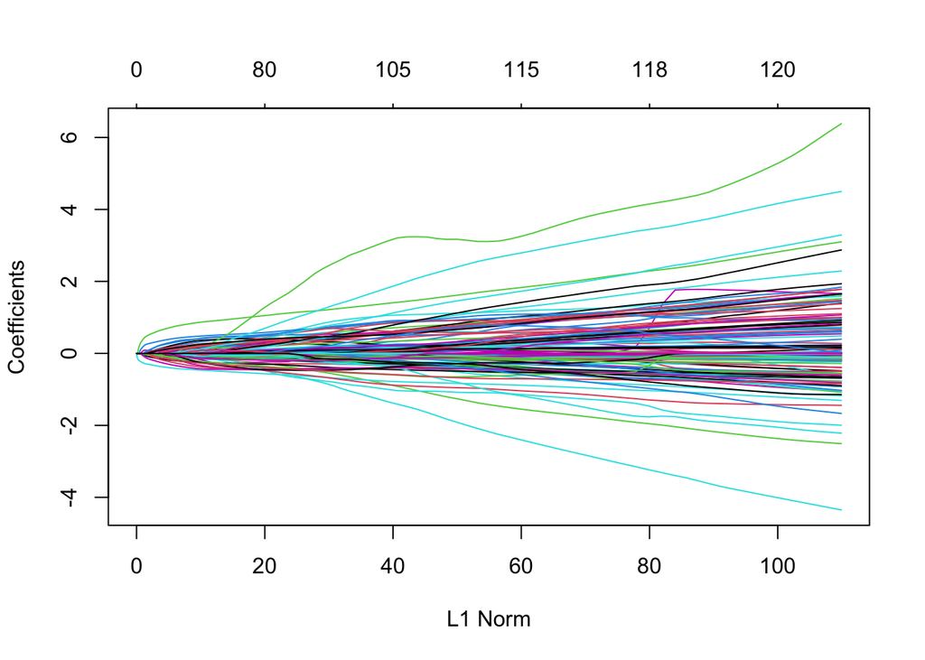

```r
# Train the LASSO model with 500 ASVs
lasso_500 <- glmnet(x = x_train_500[,-1], # take out intercept
                 y = y_train_500,
                 alpha = 1,  # Lasso
                 family = "binomial") # do not need type = class here

base::plot(lasso_500)
```

#### Cross-Validation

```r
set.seed(1234)
lasso_500_cv <- cv.glmnet(x = x_train_500[,-1], # take out intercept
                       y = y_train_500,
                       family = "binomial",
                       type.measure = "class")

lasso_500_cv
```

```
##
## Call:  cv.glmnet(x = x_train_500[, -1], y = y_train_500, type.measure = "class",      family = "binomial")
##
## Measure: Misclassification Error
##
##      Lambda Index Measure      SE Nonzero
## min 0.07045    19  0.3432 0.02195       6
## 1se 0.12311     7  0.3644 0.03269       1
```

- lambda.min has the lower misclassification rate in training of 34.3 %

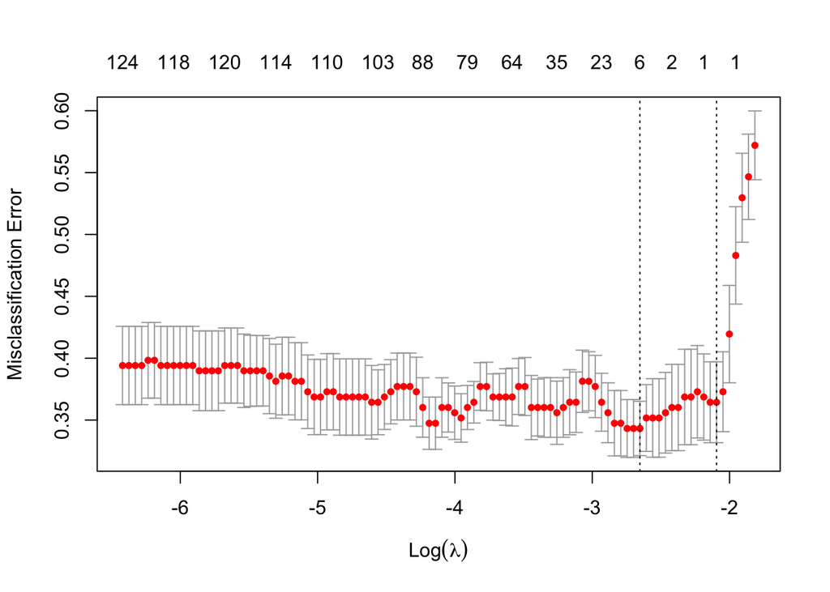

```r
base::plot(lasso_500_cv)
```

#### Best Lasso Model from Training & Cross-Validation

```r
# Refit the model with the selected lambda
best_lasso_500 <- glmnet(x = x_train_500[,-1], # take out intercept
                      y = y_train_500,
                      family = "binomial",
                      alpha = 1, # Lasso
                      lambda = lasso_500_cv$lambda.min )

best_lasso_500
```

```
##
## Call:  glmnet(x = x_train_500[, -1], y = y_train_500, family = "binomial",      alpha = 1, lambda = lasso_500_cv$lambda.min)
##
##   Df  %Dev  Lambda
## 1  6 10.13 0.07045
```

#### Lasso Testing 500

```r
dim(lr_test_500) # 42 x 502
```

```
## [1]  42 502
```

```r
x_test_500 <- stats::model.matrix(formula,
                              data = lr_test_500[,-c(1)]
                              )
y_test_500 <- lr_test_500$Clade

predict(best_lasso_500,
        newx =  x_test_500[,-1], # take out intercept bc it will fit a new one
        type = "class", # must have for misclass rate
        s = "lambda.min" # min from training cross-validation
          ) -> yhat_500
```

```r
paste("Error rate: ")
```

```
## [1] "Error rate: "
```

```r
mean((as.numeric(yhat_500) - y_test_500)^2) -> lasso_500_error
round(lasso_500_error, 2)
```

```
## [1] 0.36
```

```r
paste("Confustion Matrix: ")
```

```
## [1] "Confustion Matrix: "
```

```r
table(yhat_500, y_test_500)
```

```
##         y_test_500
## yhat_500  0  1
##        0 11  3
##        1 12 16
```

```r
paste("Correct Classification Rate: ")
```

```
## [1] "Correct Classification Rate: "
```

```r
round((11 + 16)/ 42, 2)
```

```
## [1] 0.64
```

- Testing Error rate for the lasso model with 500 ASVs is 35.7 %.
- Testing Correct Classification rate is 64.3 %

# Overall Error Rates

```r
data.frame(
  model = c("ridge_1000_error",
  "ridge_500_error",
  "lasso_1000_error",
  "lasso_500_error"),
  error_rates = c(
    ridge_1000_error,
  ridge_500_error,
  lasso_1000_error,
  lasso_500_error)
  ) %>%
  arrange(error_rates)
```

```
##              model error_rates
## 1  ridge_500_error   0.2857143
## 2 ridge_1000_error   0.3095238
## 3  lasso_500_error   0.3571429
## 4 lasso_1000_error   0.4047619
```

- The ridge classificiation model with 500 ASVs has the lowest error rate at 28.6 %.
- Correct Classification Rate: 71.4 %
- The lasso classification model with 500 ASVs has the lower of the two lasso models at 35.7 %.
- Correct Classification Rate of the Lower Lasso Model: 64.3 %.

# ASV Coefficients by Best Ridge Model for Clade C Prediction

```r
# coef(best_RR_1000, s = "lambda.min") %>%
#   as.matrix() %>%
#   as.data.frame() %>%
#   filter(s1 != 0) %>%
#   mutate(abs_coef = abs(s1)) %>%
#   arrange(-abs_coef)

coef(best_RR_500, s = "lambda.min") %>%
  as.matrix() %>%
  as.data.frame() %>%
  mutate(row_names = rownames(.)) %>%
  select(row_names, s1) %>% # reorder
  filter(s1 != 0) %>%
  mutate(abs_coef = abs(s1)) %>%
  arrange(-abs_coef) -> ridge_500_coef_df

ridge_500_coef_df
```

```
##               row_names            s1     abs_coef
## ASV6296         ASV6296  2.3009004256 2.3009004256
## ASV4003         ASV4003  1.6862780462 1.6862780462
## ASV8219         ASV8219  1.4100186678 1.4100186678
## ASV4449         ASV4449  1.3299135985 1.3299135985
## (Intercept) (Intercept)  0.8999656036 0.8999656036
## ASV0788         ASV0788  0.8596375885 0.8596375885
## ASV7777         ASV7777 -0.8594330010 0.8594330010
## ASV1238         ASV1238 -0.8167657887 0.8167657887
## ASV3075         ASV3075  0.8119653152 0.8119653152
## ASV3532         ASV3532 -0.7154355425 0.7154355425
## ASV0740         ASV0740 -0.6896935349 0.6896935349
## ASV1692         ASV1692  0.6879393178 0.6879393178
## ASV3671         ASV3671 -0.6756225039 0.6756225039
## ASV4117         ASV4117 -0.6304429463 0.6304429463
## ASV6170         ASV6170 -0.6258937366 0.6258937366
## ASV0873         ASV0873 -0.6219954185 0.6219954185
## ASV5582         ASV5582 -0.5981183101 0.5981183101
## ASV0793         ASV0793  0.5941213714 0.5941213714
## ASV4294         ASV4294  0.5691247263 0.5691247263
## ASV9859         ASV9859  0.5662114237 0.5662114237
## ASV6596         ASV6596  0.5562199629 0.5562199629
## ASV1284         ASV1284 -0.5544504708 0.5544504708
## ASV4201         ASV4201  0.5353050751 0.5353050751
## ASV2542         ASV2542  0.5255813619 0.5255813619
## ASV0958         ASV0958  0.5242003027 0.5242003027
## ASV3327         ASV3327  0.5198032785 0.5198032785
## ASV0648         ASV0648 -0.5184954752 0.5184954752
## ASV9424         ASV9424 -0.5115682102 0.5115682102
## ASV3866         ASV3866  0.5046926478 0.5046926478
## ASV3104         ASV3104  0.5025717969 0.5025717969
## ASV4195         ASV4195  0.5009139821 0.5009139821
## ASV6984         ASV6984 -0.5002104017 0.5002104017
## ASV0738         ASV0738  0.5000233433 0.5000233433
## ASV0675         ASV0675  0.4956408568 0.4956408568
## ASV1088         ASV1088  0.4947899433 0.4947899433
## ASV3512         ASV3512  0.4855784049 0.4855784049
## ASV1867         ASV1867  0.4841167284 0.4841167284
## ASV0728         ASV0728  0.4820990095 0.4820990095
## ASV13113       ASV13113  0.4458607879 0.4458607879
```

[output cut: 447 more lines]

```
## ASV0511         ASV0511 -0.0025008820 0.0025008820
## ASV0002         ASV0002 -0.0022761710 0.0022761710
## ASV0691         ASV0691  0.0017561059 0.0017561059
## ASV0097         ASV0097 -0.0015772500 0.0015772500
## ASV0017         ASV0017  0.0015188312 0.0015188312
## ASV0527         ASV0527 -0.0014702051 0.0014702051
## ASV12683       ASV12683  0.0012245779 0.0012245779
## ASV2737         ASV2737  0.0012072154 0.0012072154
## ASV0983         ASV0983 -0.0010951998 0.0010951998
## ASV6604         ASV6604 -0.0007314231 0.0007314231
## ASV0909         ASV0909  0.0005120091 0.0005120091
## ASV1150         ASV1150 -0.0004851320 0.0004851320
## ASV9557         ASV9557  0.0004474850 0.0004474850
## ASV0200         ASV0200 -0.0002803984 0.0002803984
## ASV0455         ASV0455 -0.0002763267 0.0002763267
```

```r
write_csv(ridge_500_coef_df, "../output/ridge_500_coef_df.csv")
```

# ASV Coefficients by Best Lasso Model for Clade C Prediction

```r
# coef(best_lasso_1000, s = "lambda.min") %>%
#   as.matrix() %>%
#   as.data.frame() %>%
#   filter(s1 != 0) %>%
#   mutate(abs_coef = abs(s1)) %>%
#   arrange(-abs_coef)

coef(best_lasso_500, s = "lambda.min") %>%
  as.matrix() %>%
  as.data.frame() %>%
  mutate(row_names = rownames(.)) %>%
  select(row_names, s1) %>% # reorder
  filter(s1 != 0) %>%
  mutate(abs_coef = abs(s1)) %>%
  arrange(-abs_coef) -> lasso_500_coef_df

lasso_500_coef_df
```

```
##               row_names          s1   abs_coef
## ASV0675         ASV0675  0.36072395 0.36072395
## (Intercept) (Intercept)  0.28438982 0.28438982
## ASV0013         ASV0013 -0.25135075 0.25135075
## ASV0958         ASV0958  0.16072340 0.16072340
## ASV0485         ASV0485  0.04982115 0.04982115
## ASV0120         ASV0120 -0.04638415 0.04638415
## ASV0011         ASV0011 -0.01462213 0.01462213
```

```r
write_csv(lasso_500_coef_df, "../output/lasso_500_coef_df.csv")
```

- The best lasso method with 500 possible ASV predictors selected the above ASVs as the ‘best’ predictors.